```python
from __future__ import annotations

import numpy as np
import pandas as pd

from example_models import get_linear_chain_2v
from mxlpy import Simulator, fit, make_protocol, plot
from mxlpy.distributions import LogNormal, Normal
```

from __future__ import annotations import numpy as np import pandas as pd from example_models import get_linear_chain_2v from mxlpy import Simulator, fit, make_protocol, plot from mxlpy.distributions import LogNormal, Normal

# Bayesian inference (MCMC)

A fit returns the single parameter set that best describes the data. It doesn't tell you how well the data constrain each parameter: often a whole range of values fits almost equally well.

*mxlpy* can instead **sample the posterior distribution** of the parameters given the data, using Markov chain Monte Carlo (MCMC). From the samples you get credible intervals, correlations between parameters and the uncertainty of predictions.

The posterior combines two ingredients:

- the **likelihood** of the data: the data are assumed to be the model's prediction plus Gaussian measurement noise with a known standard deviation `sigma`
- a **prior** per sampled parameter: what you know about the parameter before seeing the data, given as a distribution from `mxlpy.distributions`

## Creating synthetic data

As in the fitting tutorial, we create noisy synthetic data from a model with known parameters.

```python
model_fn = get_linear_chain_2v
true_pars = {"k1": 1.0, "k2": 2.0, "k_out": 1.0}
sigma = 0.05

clean = (
    Simulator(model_fn())
    .update_parameters(true_pars)
    .simulate_time_course(np.linspace(0, 10, 21))
    .get_result()
    .unwrap_or_err()
    .variables
)
rng = np.random.default_rng(42)
data = clean + rng.normal(0, sigma, clean.shape)

fig, ax = plot.one_axes()
for name in data.columns:
    ax.plot(data.index, data[name], "o", label=name)
ax.legend()
plot.show()
```

model_fn = get_linear_chain_2v true_pars = {"k1": 1.0, "k2": 2.0, "k_out": 1.0} sigma = 0.05 clean = ( Simulator(model_fn()) .update_parameters(true_pars) .simulate_time_course(np.linspace(0, 10, 21)) .get_result() .unwrap_or_err() .variables ) rng = np.random.default_rng(42) data = clean + rng.normal(0, sigma, clean.shape) fig, ax = plot.one_axes() for name in data.columns: ax.plot(data.index, data[name], "o", label=name) ax.legend() plot.show()

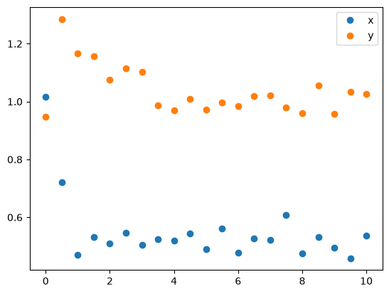

## Sampling the posterior

`fit.mcmc_time_course` takes the data, a prior for every parameter to sample and the noise level `sigma`. The keys of `prior` are the sampled parameters; all other parameters keep their model values.

Rate constants are positive and can span orders of magnitude, so a log-normal prior is a natural choice. Parameters whose prior lives on `(0, inf)` are sampled as their logarithm internally, which makes the sampler much more efficient; all results are reported in natural units.

Several independent chains run in parallel. A `seed` makes the samples reproducible.

cache

```python
res = fit.mcmc_time_course(
    model_fn(),
    data=data,
    prior={
        "k1": LogNormal(mean=0, sigma=1),
        "k2": LogNormal(mean=0, sigma=1),
        "k_out": LogNormal(mean=0, sigma=1),
    },
    sigma=sigma,
    n_samples=2000,
    n_chains=4,
    seed=0,
).unwrap_or_err()

res.chains.shape  # (chains, samples, parameters)
```

res = fit.mcmc_time_course( model_fn(), data=data, prior={ "k1": LogNormal(mean=0, sigma=1), "k2": LogNormal(mean=0, sigma=1), "k_out": LogNormal(mean=0, sigma=1), }, sigma=sigma, n_samples=2000, n_chains=4, seed=0, ).unwrap_or_err() res.chains.shape # (chains, samples, parameters)

```
(4, 2000, 3)
```

## Checking convergence

Before interpreting the samples, check that the chains have converged to the same distribution.

- **R-hat** compares the chains with each other; values below about 1.01 indicate convergence
- the **effective sample size** (ESS) estimates how many independent samples the correlated chain samples are worth; a few hundred are enough for intervals
- the **acceptance rate** of the sampler should be roughly between 0.15 and 0.5

```python
pd.DataFrame({"r_hat": res.r_hat(), "ess": res.ess()})
```

pd.DataFrame({"r_hat": res.r_hat(), "ess": res.ess()})

|  | r_hat | ess |
| --- | --- | --- |
| k1 | 1.007560 | 618.899824 |
| k2 | 1.005524 | 608.295415 |
| k_out | 1.005272 | 638.544797 |

```python
res.acceptance_rates
```

res.acceptance_rates

```
array([0.314 , 0.1725, 0.265 , 0.264 ])
```

Trace plots should look like stationary noise, with all chains overlapping.

```python
_ = res.plot_traces()
```

_ = res.plot_traces()

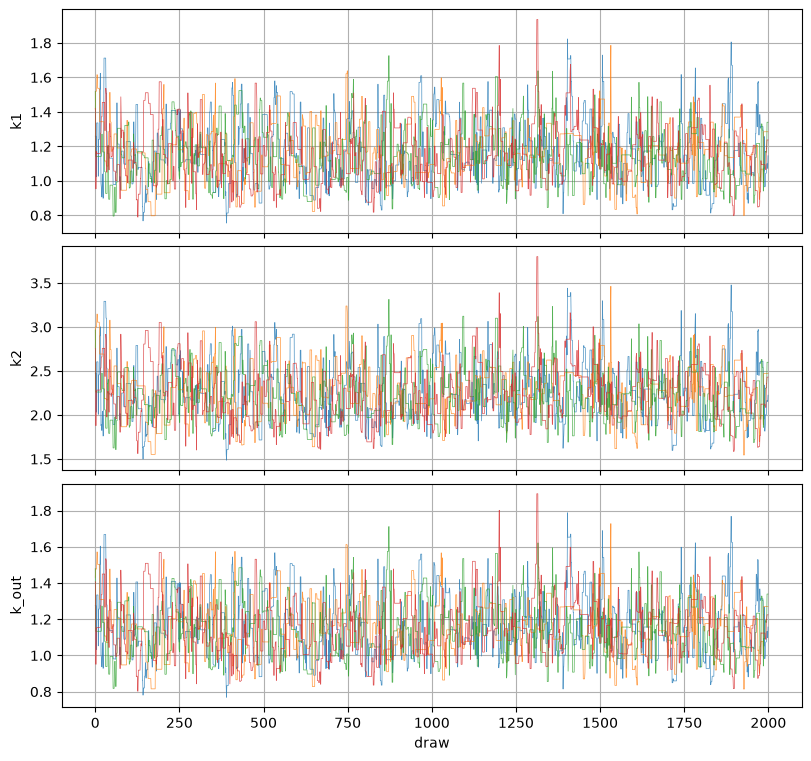

## Credible intervals

`credible_intervals` gives equal-tailed intervals containing `level` of the posterior mass, and the median.

```python
res.credible_intervals(level=0.95).assign(true=pd.Series(true_pars))
```

res.credible_intervals(level=0.95).assign(true=pd.Series(true_pars))

|  | lower | median | upper | true |
| --- | --- | --- | --- | --- |
| k1 | 0.876294 | 1.144935 | 1.510668 | 1.0 |
| k2 | 1.716410 | 2.231607 | 2.903399 | 2.0 |
| k_out | 0.885182 | 1.139038 | 1.489602 | 1.0 |

```python
_ = res.plot_marginals()
```

_ = res.plot_marginals()

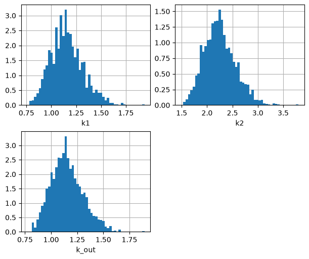

All samples are available as a `pandas.DataFrame`, one row per chain and draw. Correlations between parameters show which combinations of parameters the data constrain. Here all three rate constants are strongly correlated: the data mostly fix their ratios. Strong correlations also make the chains mix more slowly, which is why we drew 2000 samples per chain; if R-hat is too high, draw more.

```python
samples = res.samples()
samples.corr()
```

samples = res.samples() samples.corr()

|  | k1 | k2 | k_out |
| --- | --- | --- | --- |
| k1 | 1.000000 | 0.987886 | 0.996534 |
| k2 | 0.987886 | 1.000000 | 0.984949 |
| k_out | 0.996534 | 0.984949 | 1.000000 |

## Prediction uncertainty

Simulating the model for a random subset of the posterior samples propagates the parameter uncertainty to the predictions.

```python
subset = samples.sample(50, random_state=0)
predictions = pd.concat(
    {
        i: Simulator(model_fn().update_parameters(pars.to_dict()))
        .simulate_time_course(np.linspace(0, 10, 101))
        .get_result()
        .unwrap_or_err()
        .variables
        for i, pars in subset.iterrows()
    }
)
fig, ax = plot.one_axes()
for name, color in zip(data.columns, ["C0", "C1"], strict=True):
    per_time = predictions[name].unstack(level=-1)
    ax.fill_between(
        per_time.columns,
        per_time.quantile(0.025),
        per_time.quantile(0.975),
        color=color,
        alpha=0.3,
    )
    ax.plot(data.index, data[name], "o", color=color, label=name)
ax.legend()
plot.show()
```

subset = samples.sample(50, random_state=0) predictions = pd.concat( { i: Simulator(model_fn().update_parameters(pars.to_dict())) .simulate_time_course(np.linspace(0, 10, 101)) .get_result() .unwrap_or_err() .variables for i, pars in subset.iterrows() } ) fig, ax = plot.one_axes() for name, color in zip(data.columns, ["C0", "C1"], strict=True): per_time = predictions[name].unstack(level=-1) ax.fill_between( per_time.columns, per_time.quantile(0.025), per_time.quantile(0.975), color=color, alpha=0.3, ) ax.plot(data.index, data[name], "o", color=color, label=name) ax.legend() plot.show()

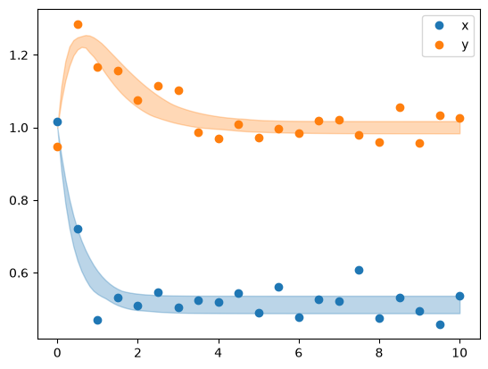

## Steady states and protocols

The steady-state and protocol variants work the same way. `sigma` can also be given per data column (or entry, for steady states) as a `pandas.Series`, or per data point as a `pandas.DataFrame`. Missing data (NaN) are ignored.

Here the steady state only constrains the ratios of the rate constants, so we fix `k1` and only sample the others.

cache

```python
steady_state = clean.iloc[-1]

res_ss = fit.mcmc_steady_state(
    model_fn(),
    data=steady_state,
    prior={"k2": LogNormal(0, 1), "k_out": LogNormal(0, 1)},
    sigma=pd.Series({"x": 0.02, "y": 0.02}),
    n_samples=1000,
    seed=0,
).unwrap_or_err()
res_ss.credible_intervals()
```

steady_state = clean.iloc[-1] res_ss = fit.mcmc_steady_state( model_fn(), data=steady_state, prior={"k2": LogNormal(0, 1), "k_out": LogNormal(0, 1)}, sigma=pd.Series({"x": 0.02, "y": 0.02}), n_samples=1000, seed=0, ).unwrap_or_err() res_ss.credible_intervals()

|  | lower | median | upper |
| --- | --- | --- | --- |
| k2 | 1.866802 | 2.007542 | 2.163379 |
| k_out | 0.964023 | 1.000896 | 1.043311 |

cache

```python
protocol = make_protocol([(4, {"k1": 1.0}), (4, {"k1": 2.0})])
data_protocol = (
    Simulator(model_fn())
    .update_parameters(true_pars)
    .simulate_protocol_time_course(protocol, time_points=np.linspace(0, 8, 33))
    .get_result()
    .unwrap_or_err()
    .variables
)

res_protocol = fit.mcmc_protocol_time_course(
    model_fn(),
    data=data_protocol + rng.normal(0, sigma, data_protocol.shape),
    protocol=protocol,
    prior={"k2": LogNormal(0, 1), "k_out": LogNormal(0, 1)},  # k1 is set by the protocol
    sigma=sigma,
    n_samples=1000,
    seed=0,
).unwrap_or_err()
res_protocol.credible_intervals()
```

protocol = make_protocol([(4, {"k1": 1.0}), (4, {"k1": 2.0})]) data_protocol = ( Simulator(model_fn()) .update_parameters(true_pars) .simulate_protocol_time_course(protocol, time_points=np.linspace(0, 8, 33)) .get_result() .unwrap_or_err() .variables ) res_protocol = fit.mcmc_protocol_time_course( model_fn(), data=data_protocol + rng.normal(0, sigma, data_protocol.shape), protocol=protocol, prior={"k2": LogNormal(0, 1), "k_out": LogNormal(0, 1)}, # k1 is set by the protocol sigma=sigma, n_samples=1000, seed=0, ).unwrap_or_err() res_protocol.credible_intervals()

|  | lower | median | upper |
| --- | --- | --- | --- |
| k2 | 1.997740 | 2.041822 | 2.090721 |
| k_out | 0.988663 | 1.002787 | 1.016704 |

## First finish line

With that you now know how to quantify parameter uncertainty with mxlpy.  
Congratulations!

## Advanced topics / customisation

### Priors

Any distribution with a `log_pdf` and a `positive_support` (the `mxlpy.distributions.Prior` protocol) can be a prior, e.g. a `Normal` for a parameter that can be negative (it is then sampled linearly), or a `Uniform` for hard bounds.

```python
Normal(loc=0, scale=1).log_pdf(0.5), Normal(loc=0, scale=1).positive_support
```

Normal(loc=0, scale=1).log_pdf(0.5), Normal(loc=0, scale=1).positive_support

```
(-1.0439385332046727, False)
```

### Starting point

By default the chains start (slightly spread out) at the model's current parameter values. Starting from a previous fit with `x0` saves warm-up time.

cache

```python
best = fit.time_course(
    model_fn(),
    p0={"k1": 1.5, "k2": 1.5, "k_out": 1.5},
    data=data,
    minimizer=fit.LocalScipyMinimizer(),
).unwrap_or_err()

res = fit.mcmc_time_course(
    model_fn(),
    data=data,
    prior={k: LogNormal(0, 1) for k in best.best_pars},
    sigma=sigma,
    x0=best.best_pars,
    n_samples=500,
    seed=0,
).unwrap_or_err()
```

best = fit.time_course( model_fn(), p0={"k1": 1.5, "k2": 1.5, "k_out": 1.5}, data=data, minimizer=fit.LocalScipyMinimizer(), ).unwrap_or_err() res = fit.mcmc_time_course( model_fn(), data=data, prior={k: LogNormal(0, 1) for k in best.best_pars}, sigma=sigma, x0=best.best_pars, n_samples=500, seed=0, ).unwrap_or_err()

### Sampler

The default sampler is `fit.AdaptiveMetropolis` (Haario et al. 2001): during a warm-up it adapts the covariance of its Gaussian proposals to the shape of the posterior, then it samples with the proposal frozen. The warm-up is discarded and defaults to as many steps as samples.

Any callable following the `fit.McmcSampler` protocol can be passed as `sampler`.

cache

```python
res = fit.mcmc_time_course(
    model_fn(),
    data=data,
    prior={k: LogNormal(0, 1) for k in true_pars},
    sigma=sigma,
    n_samples=500,
    sampler=fit.AdaptiveMetropolis(n_warmup=1000, adaptation_interval=50),
    seed=0,
).unwrap_or_err()
res.acceptance_rates
```

res = fit.mcmc_time_course( model_fn(), data=data, prior={k: LogNormal(0, 1) for k in true_pars}, sigma=sigma, n_samples=500, sampler=fit.AdaptiveMetropolis(n_warmup=1000, adaptation_interval=50), seed=0, ).unwrap_or_err() res.acceptance_rates

```
array([0.294, 0.21 , 0.266, 0.298])
```